# Explanatory Data Analysis of Red Wines Quality Dataset

# Univariate Plots Section

I have no prior knowlegde about this dataset or wines chemistry in general.

So let’s plot histograms of each variable to see if we can spot something interesting.

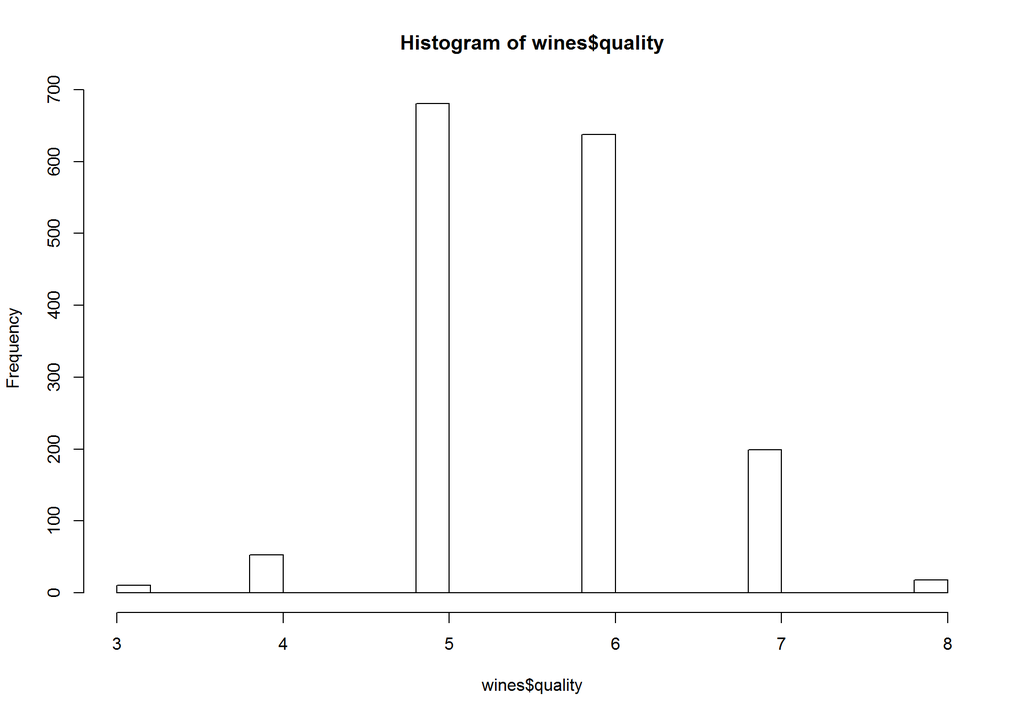

First of all distribution of quality variable – seems to be normal which is expected. We can see that most wines have average quality – 5 and 6.

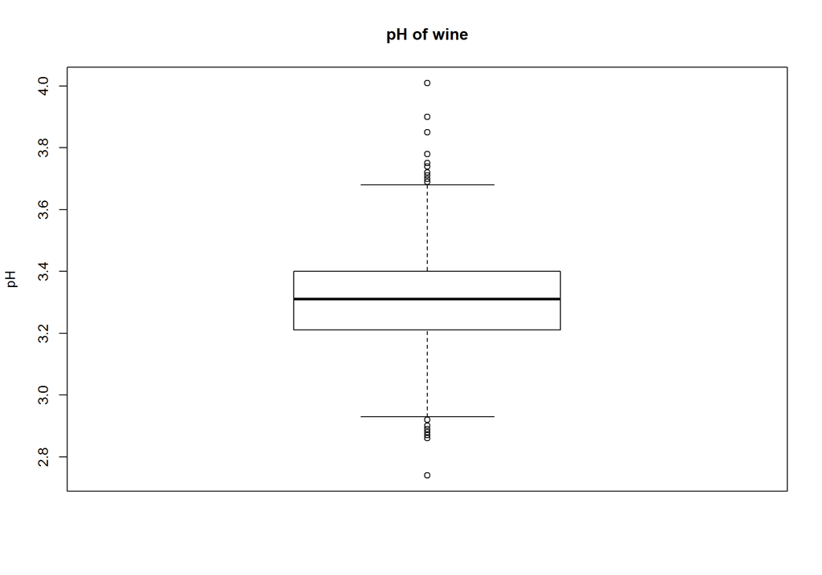

Wine pH is normally distributed in fairly narrow range. All wines are acid and majority has pH 3.3 +- 0.3. This can mean something about how wine is produced – such a small range may indicate that acidity is carefully controlled in process.

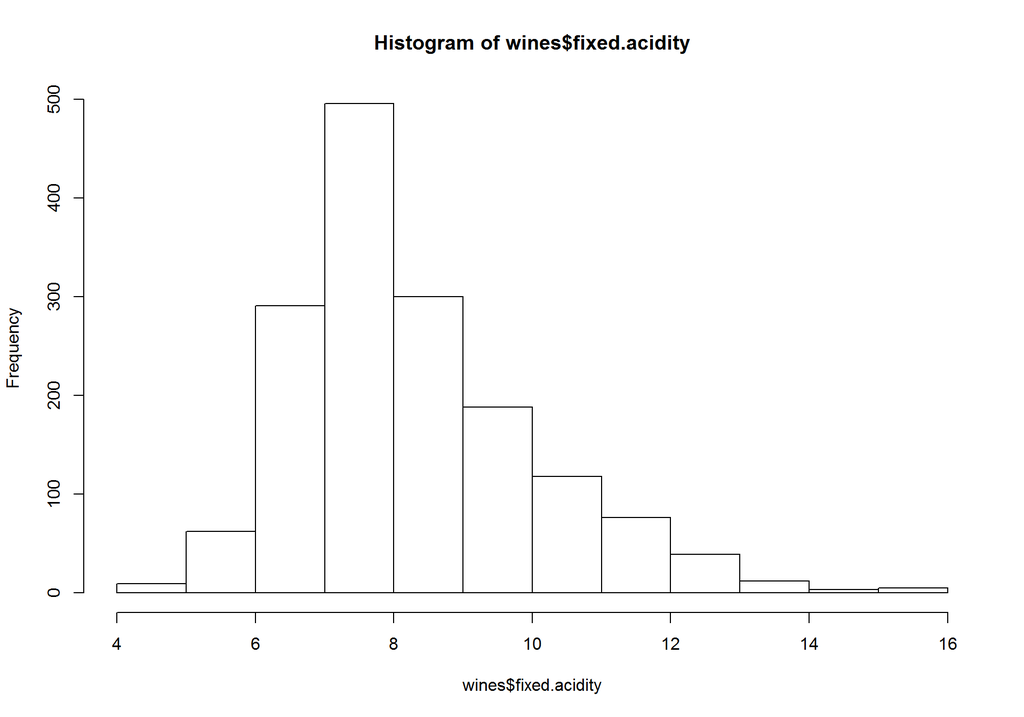

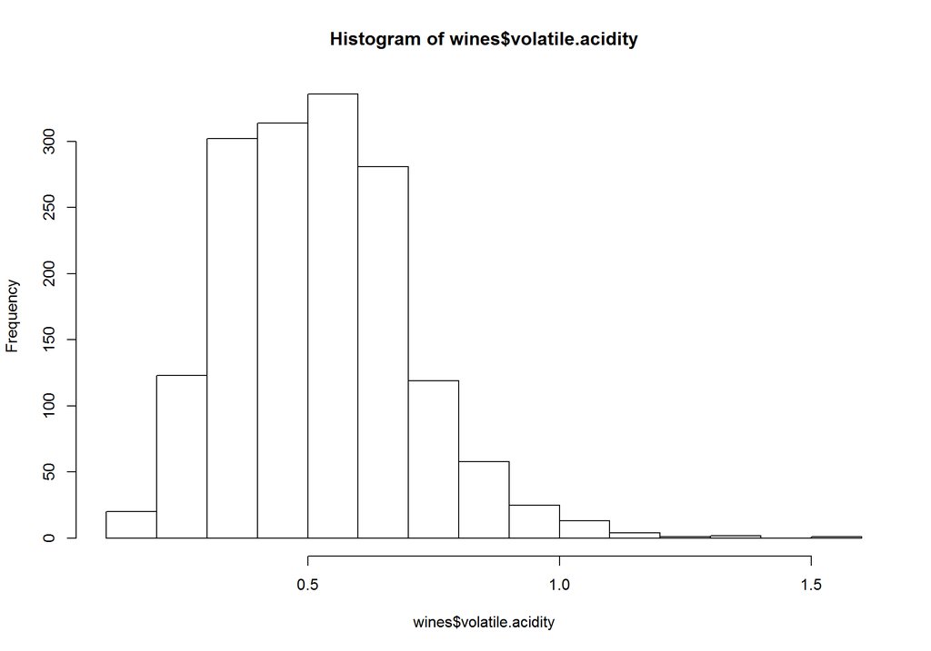

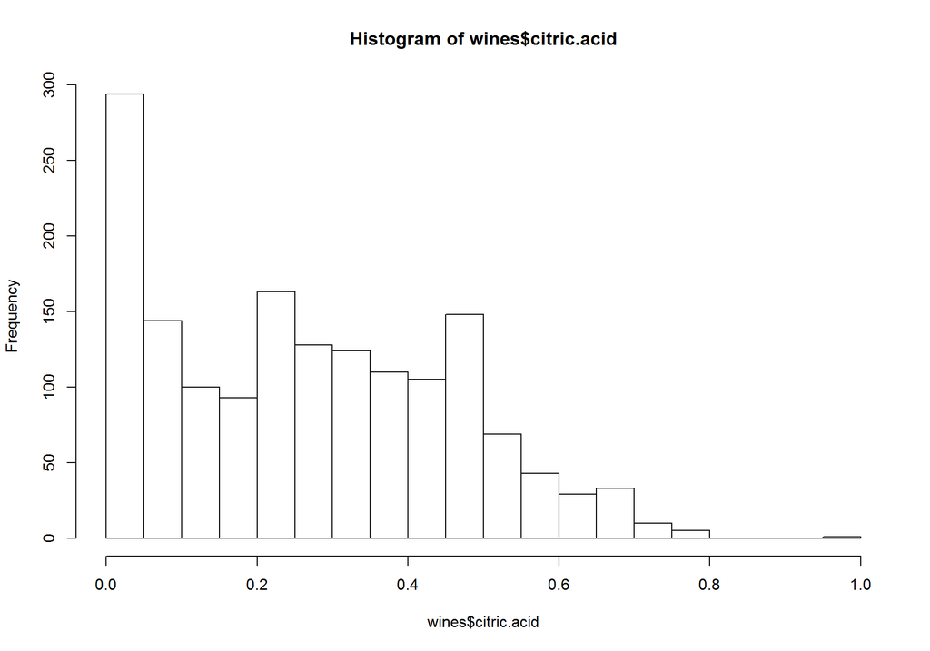

Interesting to see that many wines don’t have citric acid at all. Description to dataset says that it used to add “freshness” and flavor.

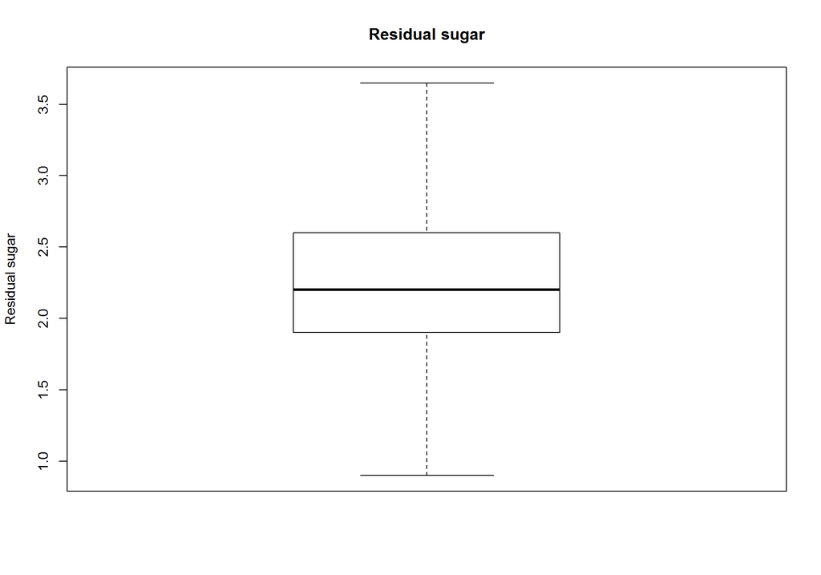

Most wines have a very little sugar between 1 and 4 gramm per liter

### Next, some less interesting variables

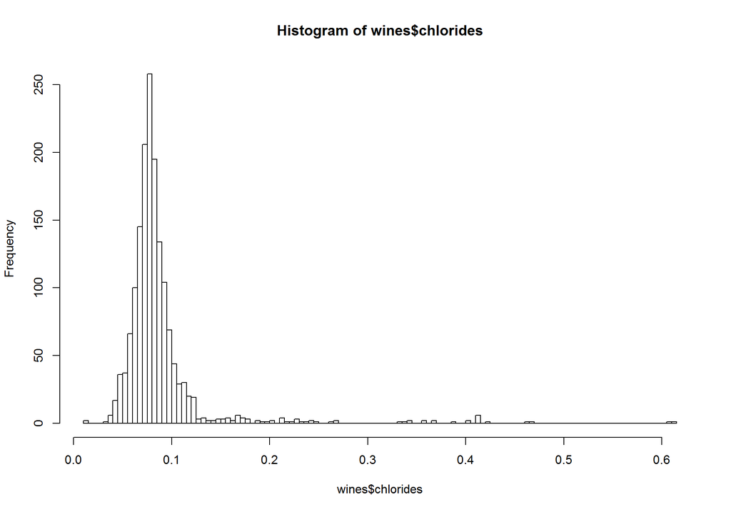

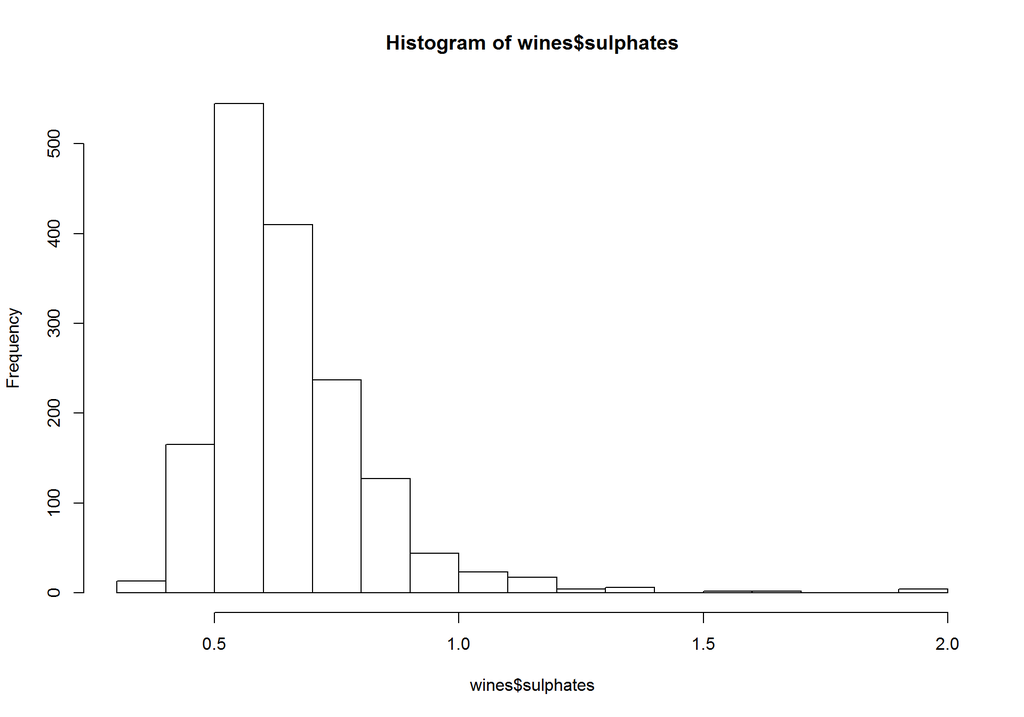

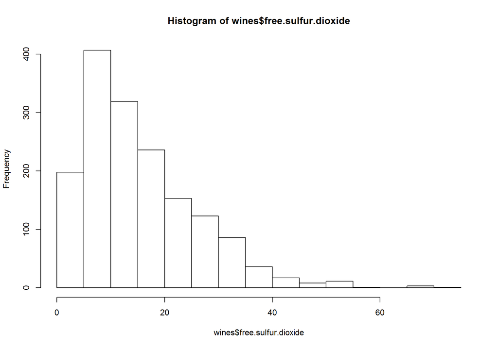

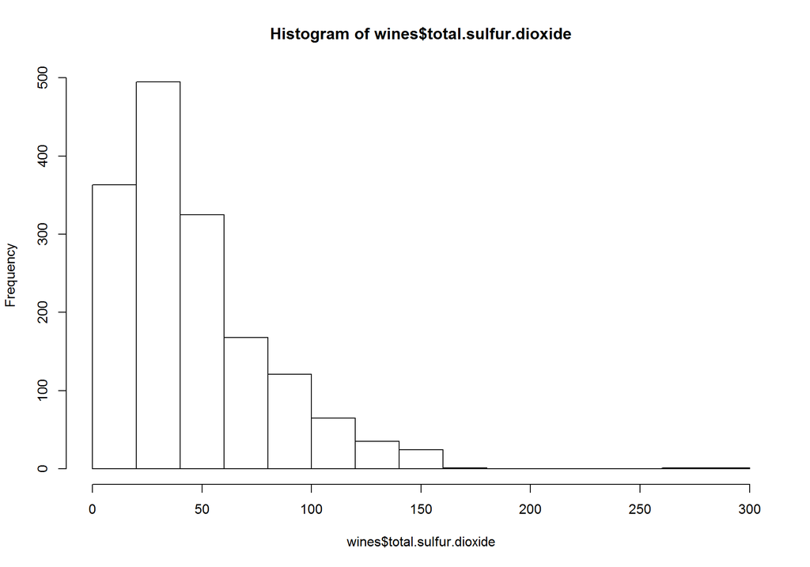

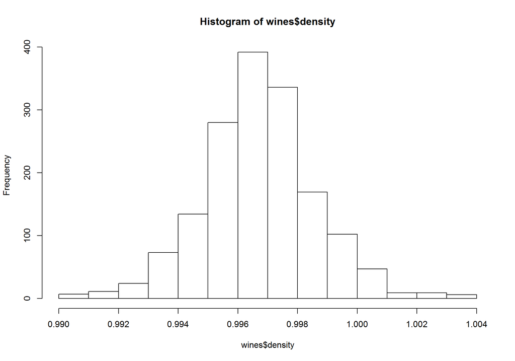

### Main aspect of drinking wine: alcohol

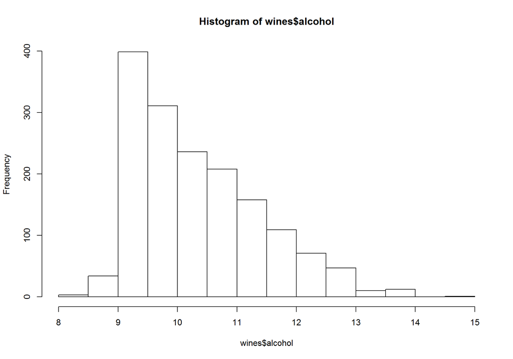

We see that distribution of alcohol quantity have some threshhold: almost no wine have less than 9% and over 14% of alcohol. Also we see gradually decreasing number of wines with increasing of alcohol.

# Univariate Analysis

### What is the structure of your dataset?

```
## 'data.frame':    1599 obs. of  12 variables:
##  $ fixed.acidity       : num  7.4 7.8 7.8 11.2 7.4 7.4 7.9 7.3 7.8 7.5 ...
##  $ volatile.acidity    : num  0.7 0.88 0.76 0.28 0.7 0.66 0.6 0.65 0.58 0.5 ...
##  $ citric.acid         : num  0 0 0.04 0.56 0 0 0.06 0 0.02 0.36 ...
##  $ residual.sugar      : num  1.9 2.6 2.3 1.9 1.9 1.8 1.6 1.2 2 6.1 ...
##  $ chlorides           : num  0.076 0.098 0.092 0.075 0.076 0.075 0.069 0.065 0.073 0.071 ...
##  $ free.sulfur.dioxide : num  11 25 15 17 11 13 15 15 9 17 ...
##  $ total.sulfur.dioxide: num  34 67 54 60 34 40 59 21 18 102 ...
##  $ density             : num  0.998 0.997 0.997 0.998 0.998 ...
##  $ pH                  : num  3.51 3.2 3.26 3.16 3.51 3.51 3.3 3.39 3.36 3.35 ...
##  $ sulphates           : num  0.56 0.68 0.65 0.58 0.56 0.56 0.46 0.47 0.57 0.8 ...
##  $ alcohol             : num  9.4 9.8 9.8 9.8 9.4 9.4 9.4 10 9.5 10.5 ...
##  $ quality             : int  5 5 5 6 5 5 5 7 7 5 ...
```

```
##  fixed.acidity   volatile.acidity  citric.acid    residual.sugar
##  Min.   : 4.60   Min.   :0.1200   Min.   :0.000   Min.   : 0.900
##  1st Qu.: 7.10   1st Qu.:0.3900   1st Qu.:0.090   1st Qu.: 1.900
##  Median : 7.90   Median :0.5200   Median :0.260   Median : 2.200
##  Mean   : 8.32   Mean   :0.5278   Mean   :0.271   Mean   : 2.539
##  3rd Qu.: 9.20   3rd Qu.:0.6400   3rd Qu.:0.420   3rd Qu.: 2.600
##  Max.   :15.90   Max.   :1.5800   Max.   :1.000   Max.   :15.500
##    chlorides       free.sulfur.dioxide total.sulfur.dioxide
##  Min.   :0.01200   Min.   : 1.00       Min.   :  6.00
##  1st Qu.:0.07000   1st Qu.: 7.00       1st Qu.: 22.00
##  Median :0.07900   Median :14.00       Median : 38.00
##  Mean   :0.08747   Mean   :15.87       Mean   : 46.47
##  3rd Qu.:0.09000   3rd Qu.:21.00       3rd Qu.: 62.00
##  Max.   :0.61100   Max.   :72.00       Max.   :289.00
##     density             pH          sulphates         alcohol
##  Min.   :0.9901   Min.   :2.740   Min.   :0.3300   Min.   : 8.40
##  1st Qu.:0.9956   1st Qu.:3.210   1st Qu.:0.5500   1st Qu.: 9.50
##  Median :0.9968   Median :3.310   Median :0.6200   Median :10.20
##  Mean   :0.9967   Mean   :3.311   Mean   :0.6581   Mean   :10.42
##  3rd Qu.:0.9978   3rd Qu.:3.400   3rd Qu.:0.7300   3rd Qu.:11.10
##  Max.   :1.0037   Max.   :4.010   Max.   :2.0000   Max.   :14.90
##     quality
##  Min.   :3.000
##  1st Qu.:5.000
##  Median :6.000
##  Mean   :5.636
##  3rd Qu.:6.000
##  Max.   :8.000
```

Dataset contains 1599 observations of 12 variables.

Description of attributes from supplementary file:

1. fixed acidity: most acids involved with wine or fixed or nonvolatile (do not evaporate readily)
2. volatile acidity: the amount of acetic acid in wine, which at too high of levels can lead to an unpleasant, vinegar taste
3. citric acid: found in small quantities, citric acid can add ‘freshness’ and flavor to wines
4. residual sugar: the amount of sugar remaining after fermentation stops, it’s rare to find wines with less than 1 gram/liter and wines with greater than 45 grams/liter are considered sweet
5. chlorides: the amount of salt in the wine
6. free sulfur dioxide: the free form of SO2 exists in equilibrium between molecular SO2 (as a dissolved gas) and bisulfite ion; it prevents microbial growth and the oxidation of wine
7. total sulfur dioxide: amount of free and bound forms of S02; in low concentrations, SO2 is mostly undetectable in wine, but at free SO2 concentrations over 50 ppm, SO2 becomes evident in the nose and taste of wine
8. density: the density of water is close to that of water depending on the percent alcohol and sugar content
9. pH: describes how acidic or basic a wine is on a scale from 0 (very acidic) to 14 (very basic); most wines are between 3-4 on the pH scale
10. sulphates: a wine additive which can contribute to sulfur dioxide gas (S02) levels, wich acts as an antimicrobial and antioxidant
11. alcohol: the percent alcohol content of the wine

Output variable (based on sensory data):

12. quality (score between 0 and 10)

### What is/are the main feature(s) of interest in your dataset?

Main feature of interest for me in this dataset is quality variable. It seems to be interesting to see what influence does other variables have on quality of wine.

### What other features in the dataset do you think will help support your investigation into your feature(s) of interest?

Based on plots made earlier and description of variables I suspect acidity variables to be important as well as alcohol and maybe other chemicals like sulfur dioxide.

### Did you create any new variables from existing variables in the dataset?

No, I didn’t create any new variables.

### Of the features you investigated, were there any unusual distributions? Did you perform any operations on the data to tidy, adjust, or change the form of the data? If so, why did you do this?

Most of variables I investigated have normal distribution, some skewed more or less. But some have unusual shape: for example alcohol distribution has clear cutoff below 9% and steady decline above. Citric acid have almost uniform distribution in range 0.0-0.5 and spike at zero.

# Bivariate Plots Section

## Let’t try some bivariate plots

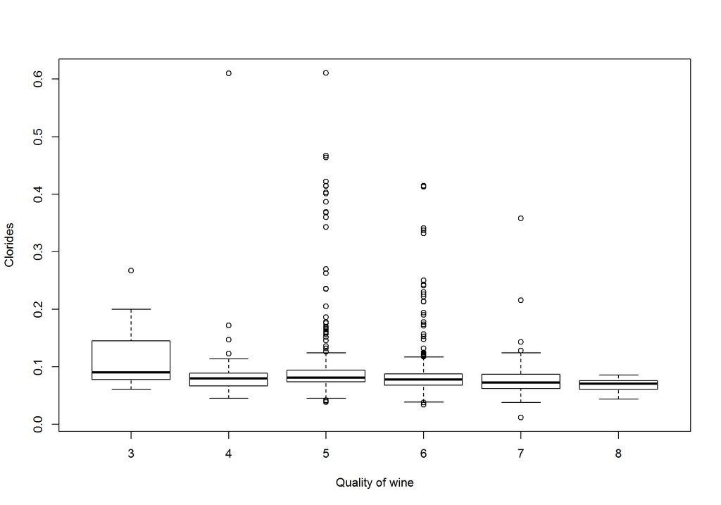

First some plots where I don’t expect much dependency: we can see at the boxplot that amount of chlorides almost the same for wines of different quality. Little exception is lowest quality wine but it can be explained by small count of samples.

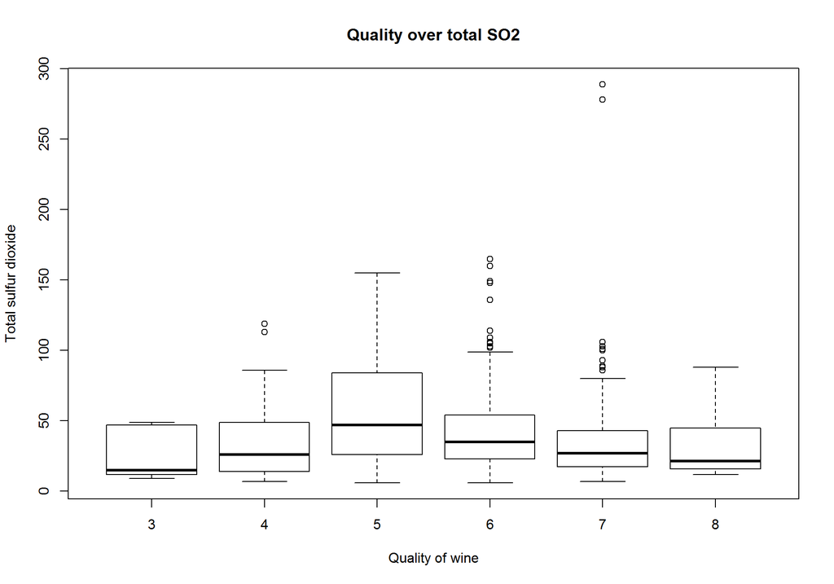

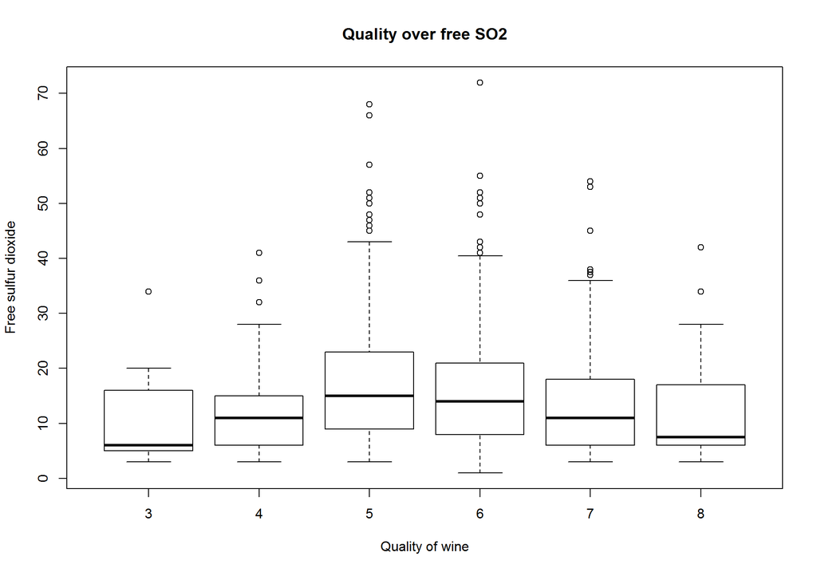

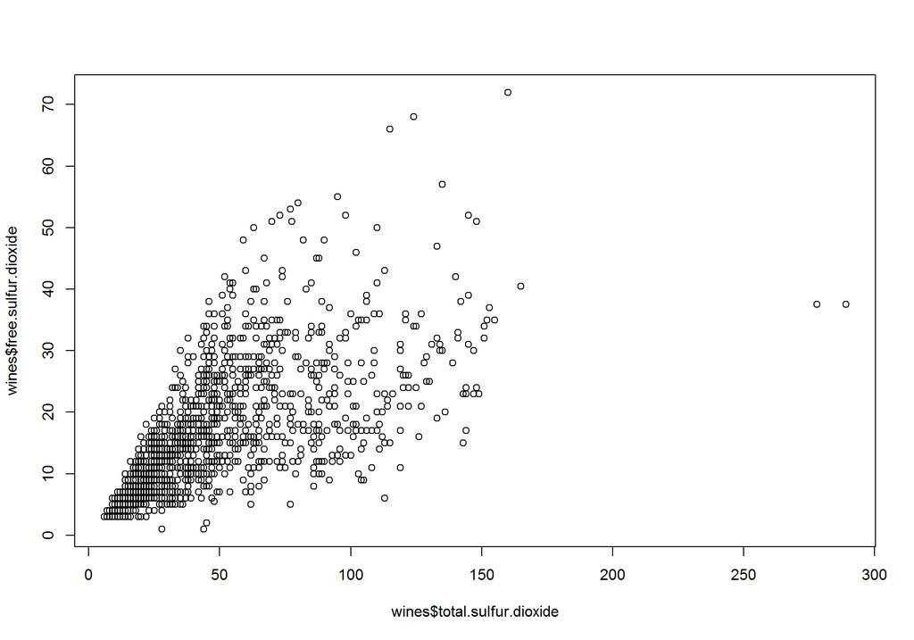

There seems to be no relation between total and free sulfur dioxide and overall quality. There is clear relation between total and free SO2 but it looks like it don’t have much effect on wine quality.

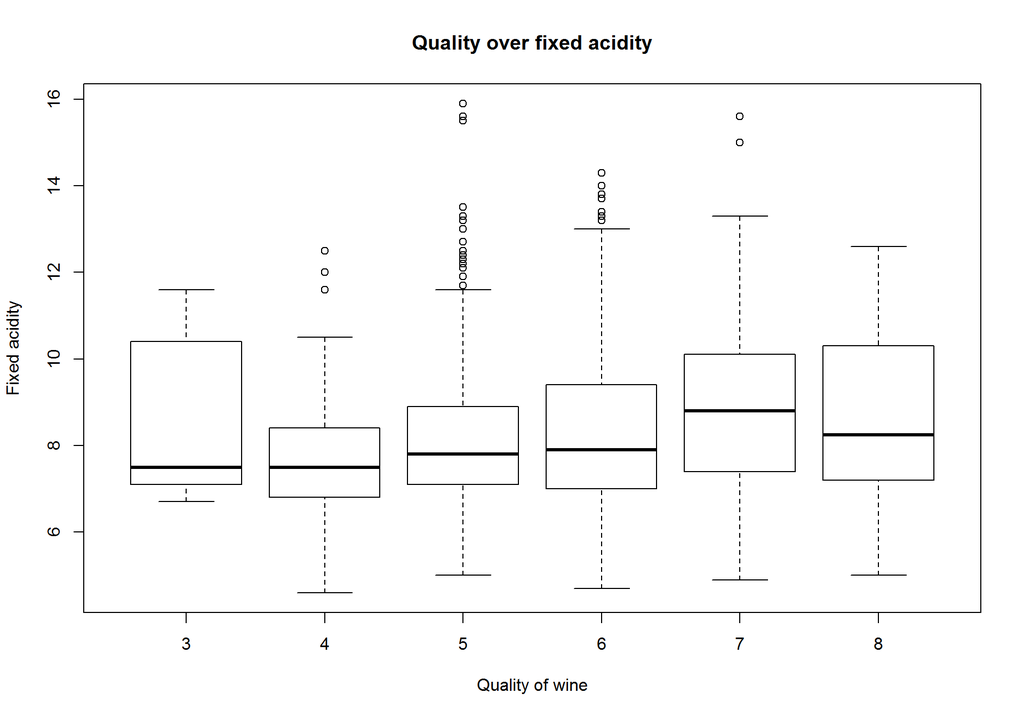

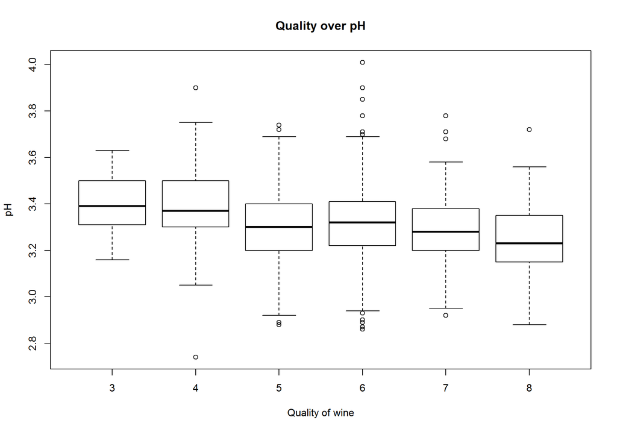

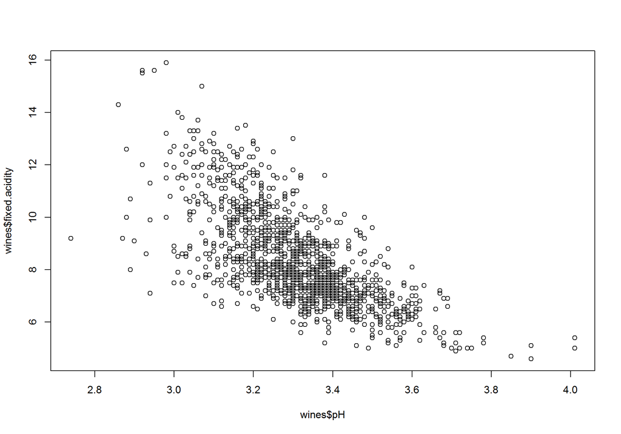

Ok, this 3 plots explore acidity a little bit. Here we see slightest increase of fixed acidity of more quality wines. As expected, pH shows reverse behavior (more acid – less pH value). If we plot relation between fixed acidity and pH we see clear correlation.

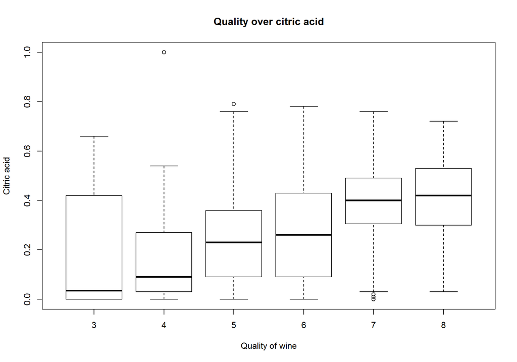

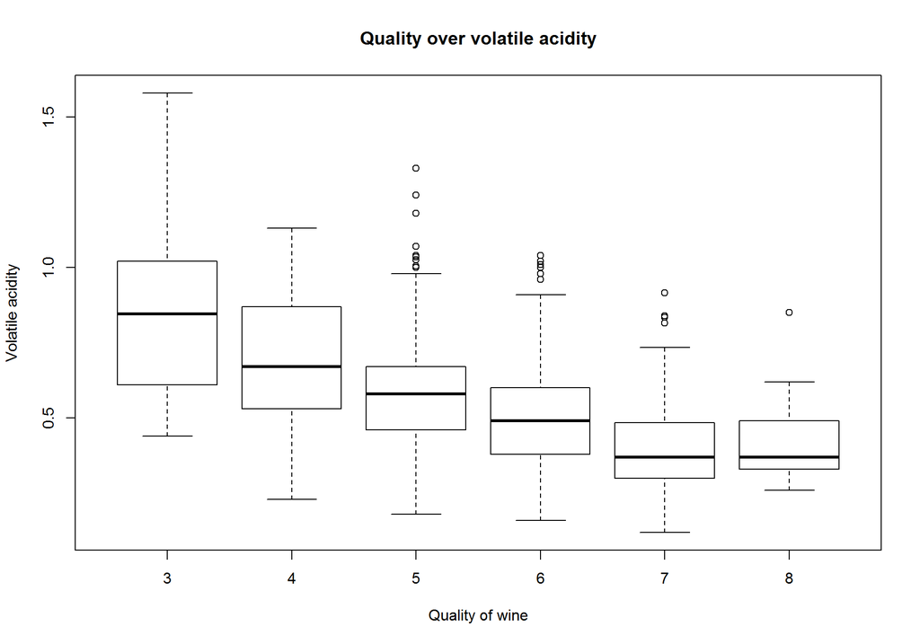

Interesting finding here – looks like citric acid and volatile acidity have strong correlation with quality. More citric acid – better quality, inverse for volatile acidity – less of it means better quality wine.

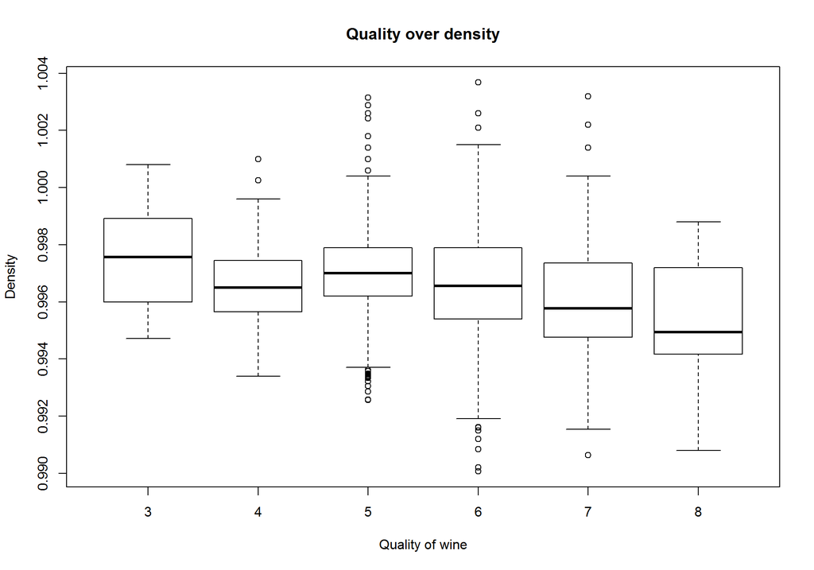

```
## [1] -0.1749192
```

Plotting density over quality reveals slight correlation between two. Density itself isn’t great predictor for quality it just proxy for chemicals in wine “solution”. Maybe decrease can be attributed to increased quantity of alcohol which is less dense than water?

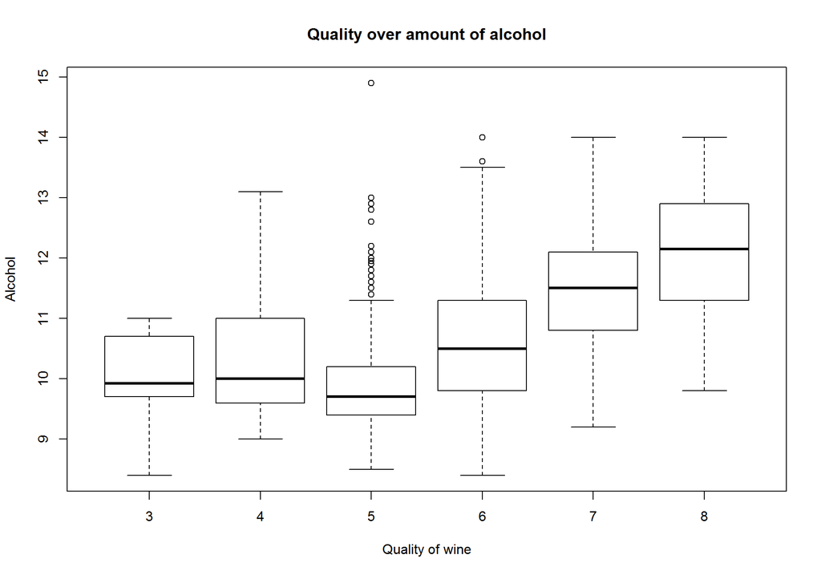

```
## [1] 0.4761663
```

Exactly! Strong enough correlation between amount of alcohol and quality.

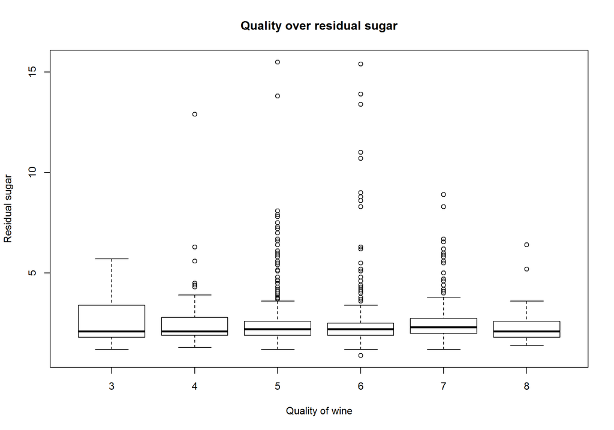

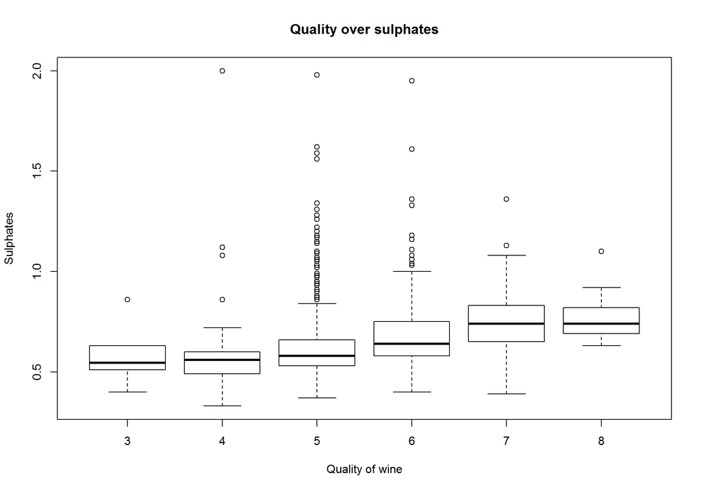

```
## [1] 0.2513971
```

Last couple of plots shows that sugar has almost no influence on quality of red wine. But amount of sulphates seems to increase with quality.

# Bivariate Analysis

### Talk about some of the relationships you observed in this part of the investigation. How did the feature(s) of interest vary with other features in the dataset?

```r
mean(wines$pH[wines$quality == 4])
```

```
## [1] 3.381509
```

```r
mean(wines$pH[wines$quality == 7])
```

```
## [1] 3.290754
```

Interesting observation is that pH changes with quality: more acid wine got higher scores. For example, wine with quality 4 has mean pH 3.381509, where wine with quality 7 has 3.290754. One possible explanation is difference in citric acid which also shows strong correlation with quality: more citric acid better the wine.

```r
mean(wines$volatile.acidity[wines$quality == 3])
```

```
## [1] 0.8845
```

```r
mean(wines$volatile.acidity[wines$quality == 8])
```

```
## [1] 0.4233333
```

In contrast, volatile acidity seems to worsen the wine. Worst wine (with quality 3) contains twice as much volatile acidity as best wine (numbers above).

Another important predictor of quality is alcohol. Suprisingly, more alcohol leads to better quality. I expected that less alcohol will mean better quality but realation is clear: best wine contains in average 2% more of alcohol. Alcohol also influence density so it too shows a little correlation with quality.

One interesting finding is how sulphates influence wine. While correlation isn’t very strong, it’s definitely there. Maybe it has something to do with antioxidant and antimicrobial qualities of this chemicals?

Other features seem to have no relationships with quality of wine.

### Did you observe any interesting relationships between the other features (not the main feature(s) of interest)?

### What was the strongest relationship you found?

```r
cor(wines$alcohol, wines$quality)
```

```
## [1] 0.4761663
```

Strongest relationship is between quality and alcohol: correlation coefficient is 0.47.

```r
cor(wines$volatile.acidity, wines$quality)
```

```
## [1] -0.3905578
```

Second strongest predictor is volatile acidity: correlation -0.39

# Multivariate Plots Section

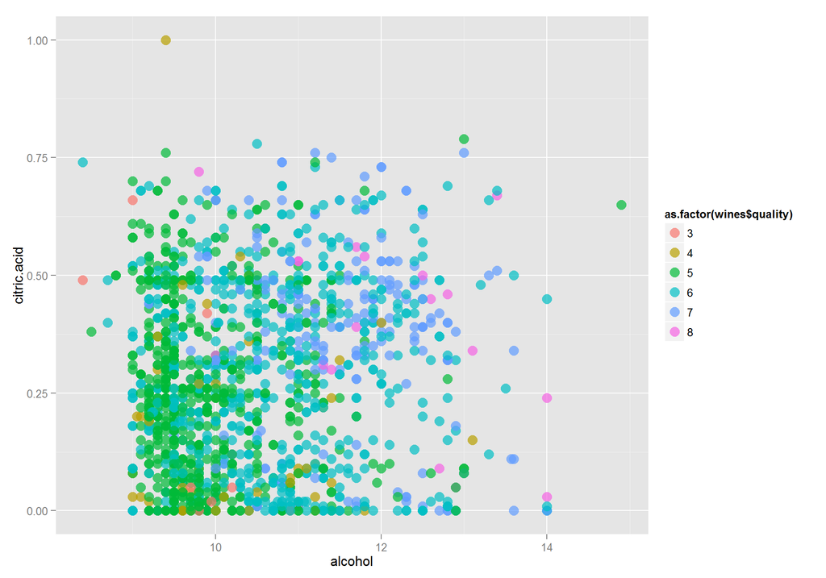

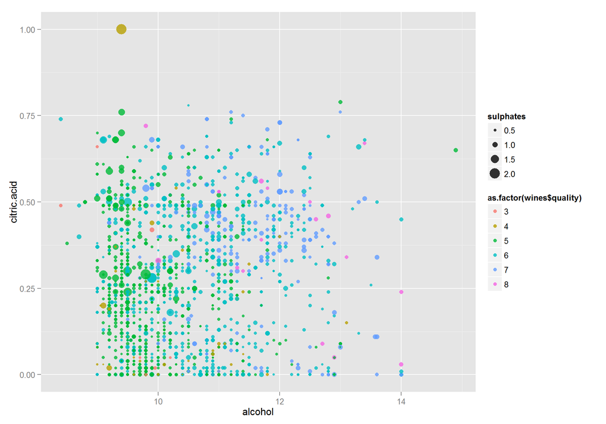

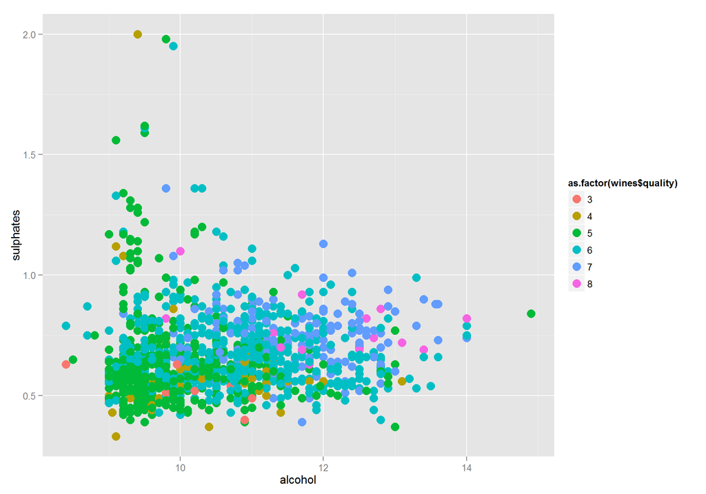

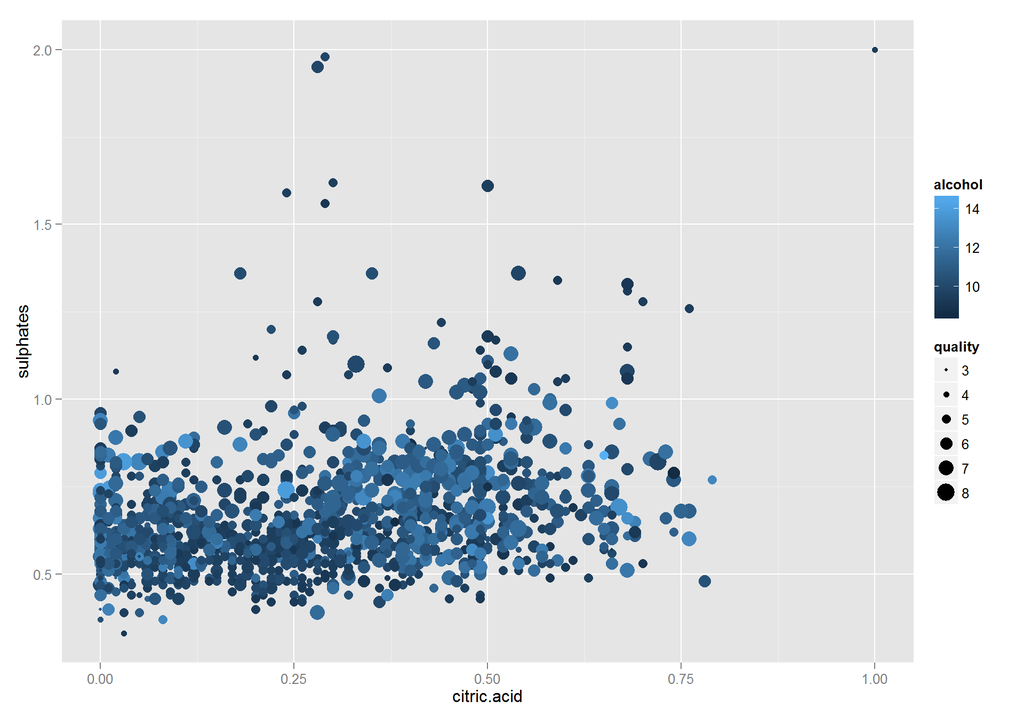

Some multivariate plots to reveal any hidden relationships.

Second shows sulphates in addition.

On third there is alcohol and sulphates without citric acid.

Forth one is kind of experiment to see how much data can be plotted at once. Totally unreadable to me.

These graphs are too much crowded and could be improved by binning quality to smaller number of categories. Let’s check.

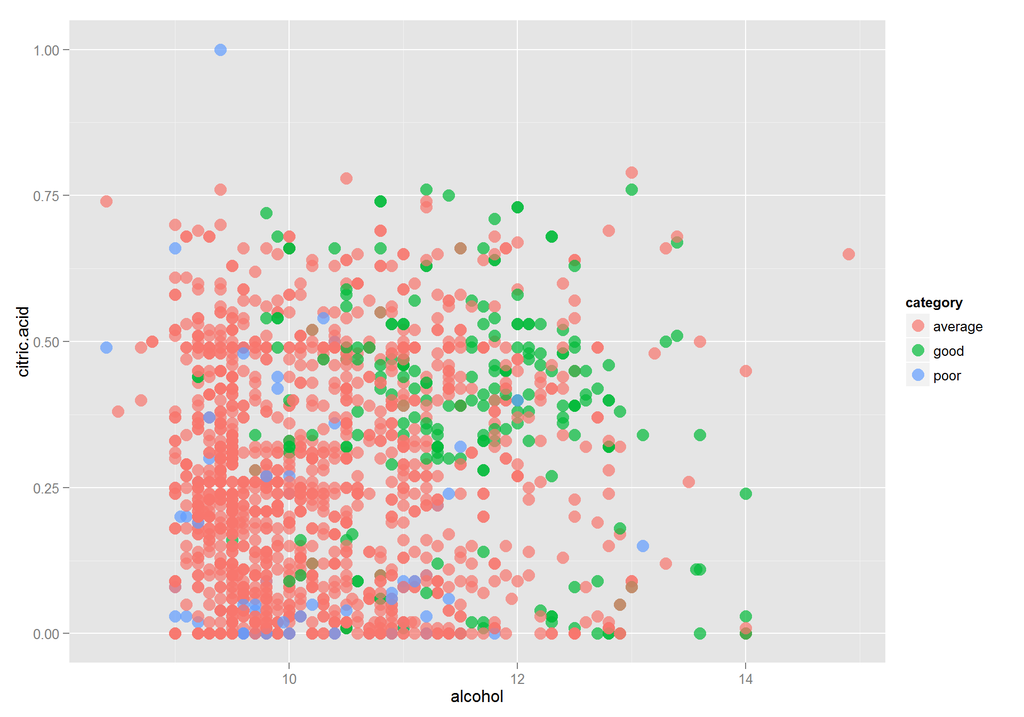

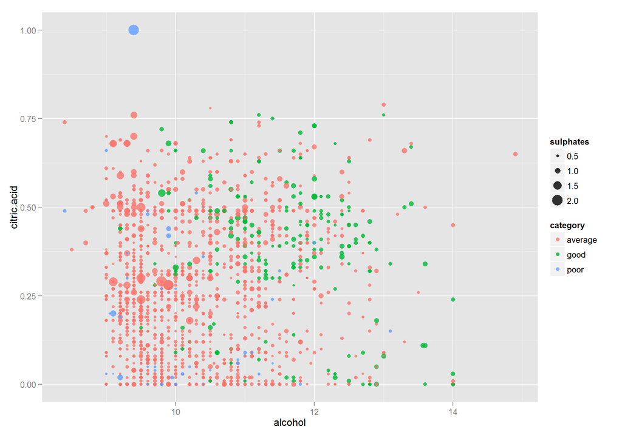

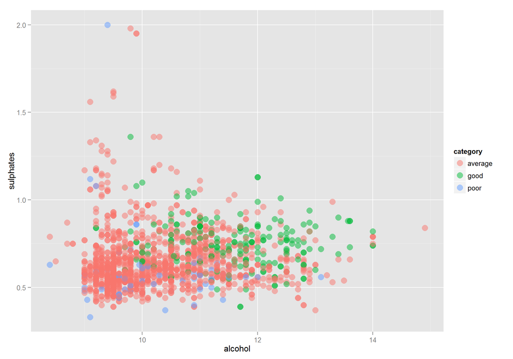

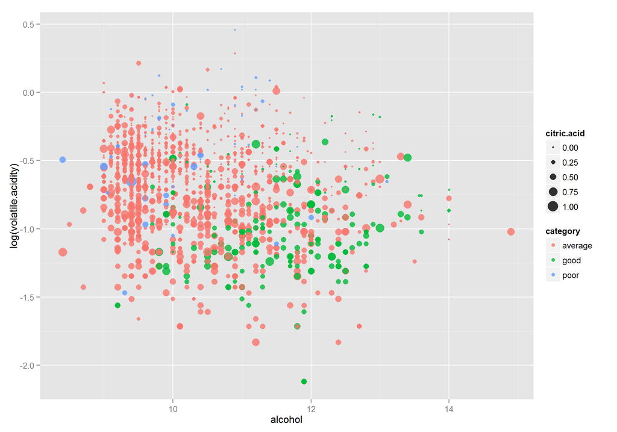

# Multivariate Analysis

### Talk about some of the relationships you observed in this part of the investigation. Were there features that strengthened each other in terms of looking at your feature(s) of interest?

From plots above we can see that for best wine we need high concentrations of two or more chemicals – alcohol and one of the following: sulphates or citric acid.

# Final Plots and Summary

### Plot One

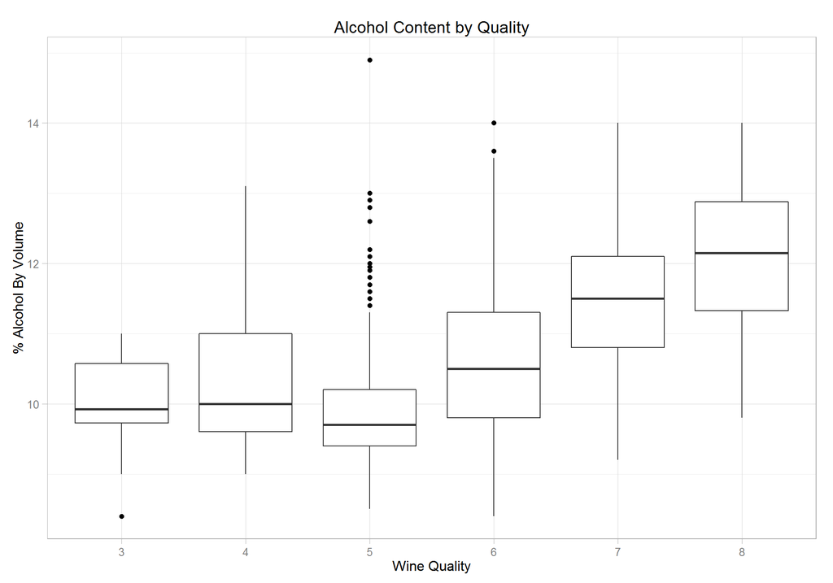

### Description One

On this plot we see most important trend in dataset: quality increases with increasing of alcohol amount in wine.

### Plot Two

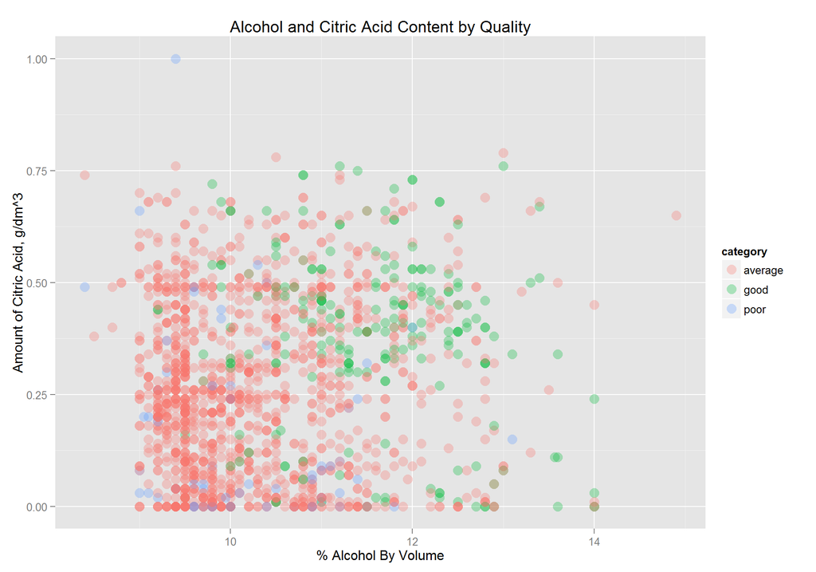

### Description Two

This plot adds one more predictor to show two of the most important relationship in this dataset at the same time: between amount of alcohol, citric acid and overall quality. On this plot we can clearly see – the more alcohol and citric acid we have – the better quality of wine.

### Plot Three

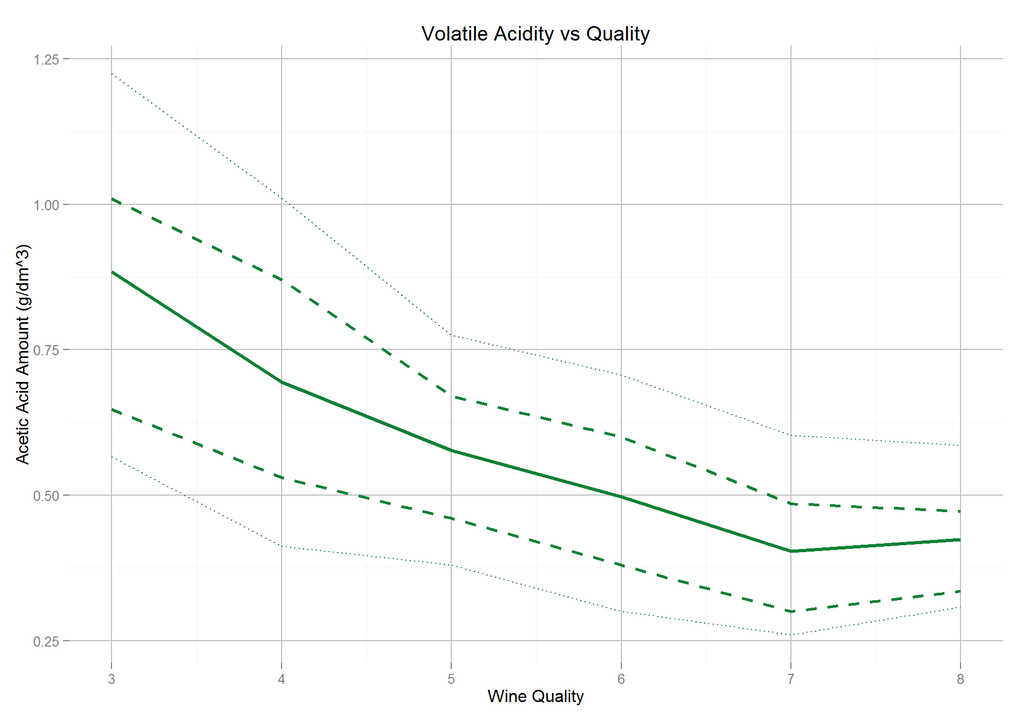

### Description Three

Last, but not least. This graph shows how quality of wime depends on amount of acetic acid. Here, we clearly see that decrease of this “unpleasant, vinegar taste” chemicals leads to better quality of wine.

# Reflection

This analysis was very insteresting and allowed me to find couple interesting things. At first it was surprising that quality of wine depends so much on amount of alcohol in it. Second surprising thing is that quality of wine depends on amounts of different acids like acetic acid and citric acid. Also, very interesting that sugar amount don’t have much influence and have so small range. Maybe in data represented only particular sort of wine?

Main struggle for me was that I wasn’t familiar with wine chemistry at all and thus had to check every single feature and make multiple plots to explore different properties of each variable. Also there is no data about sorts or wine type’s beyond that fact that all of them are red portugese wine. Year of production also not included. I think it can be valuable source of information and can predict wine quality even better than just chemical ingredients.

In the future it is possible to deepen this analysis by including some engineered features, for example, we can try plot ratios of different chemicals and see if there any relationships. Another guess may be made by building some complex “blackbox” model, like SVM with radial kernel or random forest and see if it reveals some unexpected variables interaction.